# [STA2B] : Statistique bivariée : Y qualitative et X quantitative

# 3. TEST D’EGALITE DES MOYENNES

## 3.1 Hypothèses

On considère une variable **Y quantitative continue** définie sur une population de réféence P et une variable **X qualitative à deux modalités** divisant P en deux sous population P1 et P2.

Soit par exemple la variable Y = rev et la variable X = mil. On peut se demander si les revenus des ménages urbains sont plus ou moins élevés que ceux des ménages ruraux.

```r
Y<-don3$rev
nomY <-"Revenu par personne"

X<-don3$mil
nomX <- "Milieu"
```

## 3.2 Visualisations

Le plus simple est d’utiliser **boxplot()** en version de base …

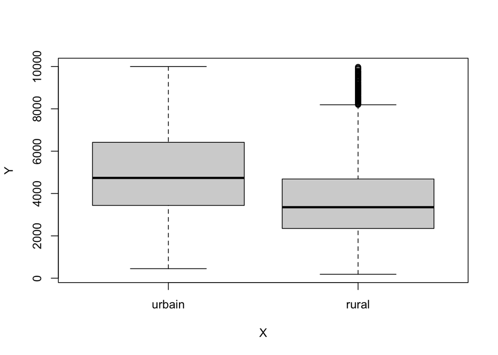

```r
boxplot(Y~X)
```

… ou améliorée

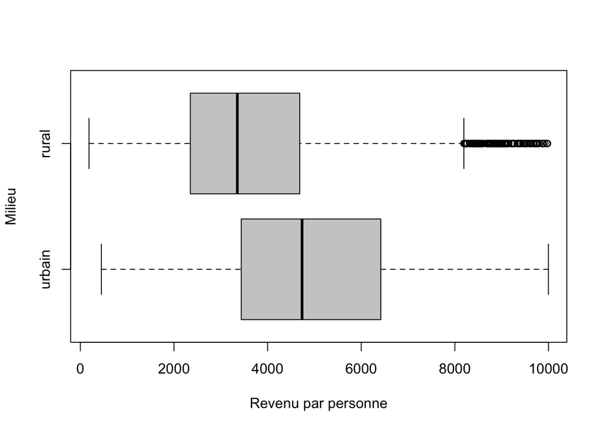

```r
boxplot(Y~X,
        horizontal=T,
        xlab = nomY,
        ylab=nomX,
        col="gray80")
```

## 3.3 Paramètres principaux

La fonction tapply() permet de calculer les paramètres statistiques de Y en fonction des modalités de X.

```r
moy<-tapply(Y,X, mean)
ect<-tapply(Y,X,sd)
cv<-100*ect/moy
res<-cbind(moy,ect,cv)
res
```

```
            moy      ect      cv
urbain 5012.590 2029.743 40.4929
rural  3684.426 1778.546 48.2720
```

## 3.4 Test d’égalité des moyennes

### Test de student

Le test de Student permet de tester l’hypothèse d’égalité des moyennes entre deux échantillons. Il suppose que la distribution est gaussienne.

```r
t.test(Y~X)
```

```
    Welch Two Sample t-test

data:  Y by X
t = 43.062, df = 14200, p-value < 2.2e-16
alternative hypothesis: true difference in means between group urbain and group rural is not equal to 0
95 percent confidence interval:
 1267.708 1388.621
sample estimates:
mean in group urbain  mean in group rural
            5012.590             3684.426
```

### Test de Wilcoxon

Le test de Wilcoxon permet également de tester l’hypothèse d’égalité des moyennes entre deux échantillons. Il ne suppose que la distribution est gaussienne car il travaille sur les rangs et non pas les valeurs.

```r
wilcox.test(Y~X)
```

```
    Wilcoxon rank sum test with continuity correction

data:  Y by X
W = 40316246, p-value < 2.2e-16
alternative hypothesis: true location shift is not equal to 0
```

# 4. ANALYSE DE VARIANCE

## Que faire lorsque X a plus de deux modalités ?

Supposons que nous voulions maintenant examiner la relation entre revenu et niveau d’instruction. On une peut commencer par réaliser une boxplot comme précédemment :

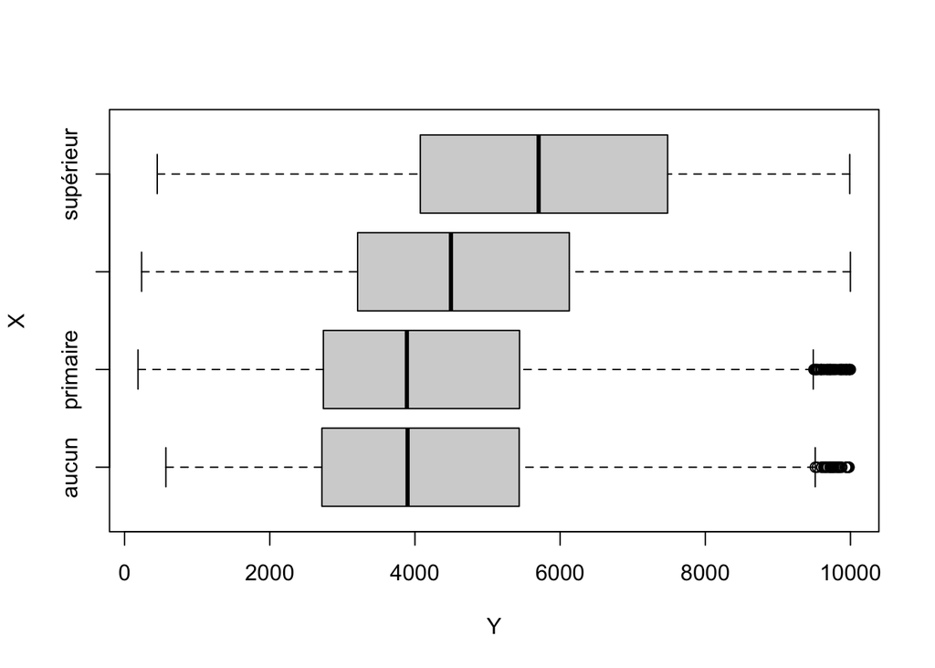

```r
Y<-don3$rev
nomY <-"Revenu par personne"
X<-don3$ins
nomX <- "Niveau d'instruction"

boxplot(Y~X, horizontal=T)
```

On peut également construire un tableau de paramètres par modalités

```r
moy<-tapply(Y,X, mean)
ect<-tapply(Y,X, sd)
cv=100*moy/ect

param<-data.frame(moy,ect,cv)

param
```

```
                moy      ect       cv
aucun      4216.892 1957.342 215.4398
primaire   4232.572 1951.893 216.8444
secondaire 4769.130 2032.135 234.6857
supérieur  5787.599 2162.304 267.6588
```

## Impossible d’utiliser le test d’égalité de deux moyennes

Le test d’égalité des moyennes ne fonctionne que lorsque la variable qualitative Y n’a que deux modalités. On ne peut donc pas l’appliquer pour étudier la relation entre le revenu (Y) et le niveau d’instruction (X) car celui-ci comporte 4 modalités.

Le programme suivant provoquera une erreur :

```r
t.test(Y~X)
```

Error in t.test.formula(Y ~ X) : grouping factor must have exactly 2 levels

## Solution générale : l’analyse de variance

```r
Y<-don3$rev
modele <- lm(Y~X)
summary(modele)
```

```
Call:
lm(formula = Y ~ X)

Residuals:
    Min      1Q  Median      3Q     Max
-5337.6 -1522.6  -304.9  1293.3  5766.4

Coefficients:
            Estimate Std. Error t value Pr(>|t|)
(Intercept)  4216.89      33.25  126.81   <2e-16 ***
Xprimaire      15.68      41.24    0.38    0.704
Xsecondaire   552.24      45.46   12.15   <2e-16 ***
Xsupérieur   1570.71      65.75   23.89   <2e-16 ***
---
Signif. codes:  0 '***' 0.001 '**' 0.01 '*' 0.05 '.' 0.1 ' ' 1

Residual standard error: 1992 on 15614 degrees of freedom
Multiple R-squared:  0.04776,   Adjusted R-squared:  0.04758
F-statistic:   261 on 3 and 15614 DF,  p-value: < 2.2e-16
```

Cette méthode étant plus complexe on attendra le cours sur la modélisation pour la discuter plus en détail.

# A VOUS DE JOUER

## Sexe du chef de ménage et revenu

Vous devez analyser l’existence d’une relation entre les variables revenu moyen annuel du ménage (Y) et sexe du chef de ménage (X).

Quelle est votre hypothèse H1 ?

Quelle est votre hypothèse H0 ?

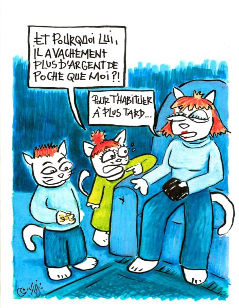

flouze